# Object-oriented scientific programming with C++

Matthias Möller, Jonas Thies, Cálin Georgescu, Jingya Li (Numerical Analysis, DIAM)

Lecture 2

# Task: Dot product

Write a C++ code that computes the dot product $$ a \cdot b=\sum_{i=1}^n a_i b_i $$ of two vectors $a=\left[a_1, a_2, \ldots, a_n\right]$ and $b=\left[b_1, b_2, \ldots, b_n\right]$ and terminates if the two vectors have different length.

# Dot product function

The main functionality of the `dot_product` function without any fail-safe checks

```
double dot_product(const double* a, int n, const double* b, int m)
{
    double d=0.0;
    for (auto i=0; i<n; i++)
        d += a[i]*b[i];
    return d;
}
```

# Dot product function - improved version

First version of the `dot_product` function *with* fail-safe checks

```
#include <exception>

double dot_product(const double* a, int n, const double* b, int m)
{
    if (a == nullptr || b == nullptr) {
        // Handle null pointers by throwing an exception
        throw std::invalid_argument("Null pointer argument");
    }

    if (n != m) {
        // Handle mismatched sizes by throwing an exception
        throw std::invalid_argument("Array sizes mismatch");
    }

    // Core functionality
    double d = 0.0;
    for (int i = 0; i < n; ++i) {
        d += a[i] * b[i];
    }
    return d;
}
```

Creation of two vectors and use of the `dot_product` function

```
#include <iostream>

double x[5] = { 1, 2, 3, 4, 5 };
double y[4] = { 1, 2, 3, 4 };

try {
    double d = dot_product(x, 5, y, 4);
} catch (const std::exception &e) {
    std::cout << e.what() << std::endl;
}
```

It would be much better if `x` and `y` would "know" their length internally so that the calling function cannot provide inconsistent data

# Cool! But what was the reason I enrolled in this course?

[figure not shown]

# Flashback: Object Oriented Programming

Imagine each LEGO block as a piece of data (like an integer, string, etc.). A `struct` or a `class` is like a LEGO set that contains a variety of different blocks.

- OOP: bundle data (e.g. `array`) and functionality (e.g. `length`) into a `struct` or `class`
- Components of a struct are `public` (=can be accessed from outside the struct) by default
- Components of a class are `private` (=cannot be accessed from outside the class) by default
- Components of a struct/class are attributes and member functions (=methods)

# Class vs. struct

```
class Vector {
    private: //default
    public:
        double* array;
        int length;
};
```

```
struct Vector {
    public: // default
        double* array;
        int length;
    private:
};
```

**When to use `class` and when to use `struct`?**

- `struct` is typically used when you want to group data together without needing to restrict access to it. It is straightforward and simple. Many type traits (later in this course) are implemented as `struct`s.
- `class` is typically used when you want more control over the data and the interface through which it is accessed and manipulated, promoting the principles of encapsulation and data hiding.

# Dot product as a member function of Vector

Second version of the `dot_product` function

```
#include <exception>

class Vector {
    public:
        double* array;
        int length;

    double dot_product(const Vector& a, const Vector& b)
    {
        if (a.length != b.length)
            throw std::invalid_argument("Vector lengths mismatch");

        double d=0.0;
        for (auto i=0; i<a.length; i++)
            d += a.array[i]*b.array[i];
        return d;
    }
};
```

Access of members of a `struct` or `class` by **dot-notation (".")**

Is the above implementation really OOP? How would you invoke it from the main program?

```
#include <iostream>

Vector x,y;
x.array = new double[5]; x.length = 5;
y.array = new double[5]; y.length = 5;

for (int i = 0; i < 5; ++i) {
    x.array[i] = i + 1;  // 1, 2, 3, 4, 5
    y.array[i] = i + 1;  // 1, 2, 3, 4, 5
}

try {
    double result = /** ??? **/;
} catch (const std::exception &e) {
    std::cout << e.what() << std::endl;
}
```

The current implementation of the `dot_product` function comes from functional programming and is not OOP style because it takes two input arguments `x` and `y` and returns one output argument, the dot product. In other words, it is not attached to any object (`x` or `y`).

If we want to implement a function inside a `class` or `struct` that is not attached to an object we have to define it as `static`

```
#include <exception>

class Vector {
    public:
        double* array;
        int length;

    static double dot_product(const Vector& a, const Vector& b)
    {
        if (a.length != b.length)
            throw std::invalid_argument("Vector lengths mismatch");

        double d=0.0;
        for (auto i=0; i<a.length; i++)
            d += a.array[i]*b.array[i];
        return d;
    }
};
```

`static` member functions are invoked with the full classname (comparable to namespaces)

```
#include <iostream>

Vector x,y;
x.array = new double[5]; x.length = 5;
y.array = new double[5]; y.length = 5;

for (int i = 0; i < 5; ++i) {
    x.array[i] = i + 1;  // 1, 2, 3, 4, 5
    y.array[i] = i + 1;  // 1, 2, 3, 4, 5
}

try {
    double result = Vector::dot_product(x, y);
} catch (const std::exception &e) {
    std::cout << e.what() << std::endl;
}
```

- It is still possible to initialise `x.length` by the wrong value, e.g.,

  ```
  x.array = new double[5] {1, 2, 3, 4, 5};
  x.length = 4;
  ```

- The main function is not very readable due to the lengthy declaration, initialization and deletion of data
- OOP solution:
  - **Constructor(s):** method to construct a new Vector object
  - **Destructor:** method to destruct an existing Vector object

# Constructor

The **constructor** is called each time a new Vector object (=instance of the class Vector) is created

```
class Vector
{
    public:
        double* array;
        int length;

    Vector() // Default constructor
    {
        array = nullptr;
        length = 0;
    }
};
```

A class can have **multiple constructors** if they have a different interface (=different parameters)

```
class Vector
{
    public:
        double* array;
        int length;

    Vector() // Default constructor
    {
        array = nullptr;
        length = 0;
    }

    Vector(int len) // Another constructor
    {
        array = new double[len];
        length = len;
    }
};
```

What if a parameter has the same name as an attribute?

```
class Vector
{
    public:
        double* array;
        int length;

    Vector(int length) // Another constructor
    {
        // The 'this' pointer refers to the object itself,
        // hence this->length is the attribute and length
        // is the parameter passed to the constructor

        array = new double[length];
        this->length = length;
    }
};
```

# Destructor

The **destructor** is called implicitly at the end of the lifetime of a Vector object, e.g., at the end of its scope

```
class Vector
{
    public:
        double* array;
        int length;

    ~Vector() // Destructor (and there can be only one!)
    {
        delete[] array;
        length = 0;
    }
};
```

Cleaning up the main program with constructors and (implicitly invoked) destructors

```
int main(){
    Vector x; // Default constructor is called
    {
        Vector y(5); // Constructor is called
        // Destructor is called for Vector y
    }
    // Destructor is called for Vector x
  }
```

Without `array = nullptr` in the default constructor the destruction of `x` will lead to a run-time error.

# Uniform initialisation constructors (C++11)

Remember this `double x[5] = { 1, 2, 3, 4, 5 };`

It would be cool to simply write `Vector x = { 1, 2, 3, 4, 5 };`

C++11 solution: **initializer lists**

```
Vector(const std::initializer_list<double> list) {
    length = (int)list.size();
    array = new double[length];
    std::uninitialized_copy(list.begin(), list.end(), array);
}
```

```
#include <initializer_list>
#include <memory>

class Vector {
private:
    double* array;
    int length;

public:
    // Constructor with initializer list
    Vector(const std::initializer_list<double>& list)
    {
        length = (int)list.size();
        array = new double[length];
        std::uninitialized_copy(list.begin(), list.end(), array);
    }

    // Destructor
    ~Vector() {
        delete[] array;
    }
};
```

# Dot product – close to perfection

Third version of the dot product using Vector class with **uniform initialisation constructor** (C++11) and exceptions

```
int main()
{
    Vector x = { 1, 2, 3, 4, 5 };
    Vector y = { 2, 4, 6, 8, 10};
    try {
        double dot_product(x, y);
        } catch (const std::exception &e) {
    std::cout << e.what() << std::endl;
    }
}
```

# Delegating constructor (C++11)

Can we delegate some of the work?

```
#include <memory>
#include <initializer_list>

class Vector {
private:
    double* array;
    int length;

public:
    Vector(int length)
    {
        this->length = length;
        array = new double[length];
    }

    Vector(const std::initializer_list<double>& list)
    {
        length = (int)list.size();
        array = new double[length];
        std::uninitialized_copy(list.begin(), list.end(), array);
    }
}
```

**Delegating constructors** delegate part of the work to another constructor of the same or another class

```
Vector(int length)
    : length(length), array(new double[length])
{ }
```

- Here, delegation is not really helpful but more a question of coding style, e.g., some programmers use delegation in all situation where this is technically possible
- It is no longer necessary to distinguish between the **attribute** (`this->length`) and the **argument** (`length`) if both have the same name. But be careful with the order in which delegated objects are constructed!

# Quiz: Which of the following codes is wrong?

- Code 1

  ```
  Vector(int len)
      : length(len),
        array(new double[len])
    {}
  ```

- Code 2

  ```
  Vector(int len)
      : array(new double[len]),
        length(len)
    {}
  ```

- Code 3

  ```
  Vector(int len)
      : length(len),
        array(new double[lengh])
    {}
  ```

- Code 4

  ```
  Vector(int len)
    : array(new double[length]),
      length(len)
    {}
  ```

If you have multiple constructors with increasing functionality, **delegating constructors** can be really helpful to remove duplicate code, e.g.

```
Vector(const std::initializer_list<double>& list)
    : Vector((int)list.size())
    {
        std::uninitialized_copy(list.begin(), list.end(), array);
    }
```

# Turning a stand-alone function into a member function

Function that computes the sum of a Vector

```
static double sum(const Vector& a)
{
    double s = 0;
    for (auto i=0; i<a.length; i++)
        s += a.array[i];
    return s;
}
```

This is not really OOP-style!

```
int main() {
 Vector x = { 1, 2, 3, 4, 5 };
 std::cout << sum(x) << std::endl;
}
```

# Implementation of `sum` as an OOP-style member function

```
#include <memory>
#include <initializer_list>

class Vector {
    private:
        double* array;
        int length;

    public:
        Vector(const std::initializer_list<double>& list) {
            length = static_cast<int>(list.size());
            array = new double[length];
            std::uninitialized_copy(list.begin(), list.end(), array);
        }

        ~Vector() {
            delete[] array;
        }

        double sum() {
            double s = 0;
            for (int i = 0; i < length; i++) {
                s += array[i];
            }
            return s;
        }
};
```

This is good OOP-style

```
Vector v = {1, 2, 3};
std::cout << v.sum() << std::endl;
```

Can we implement the `dot_product` function as a member function?

```
#include <exception>

class Vector {
    private:
        double* array;
        int length;

    public:
        double dot_product(const Vector& other) {
            if (length != other.length)
                throw std::invalid_argument("Vector lengths mismatch");

            double d=0.0;
            for (auto i=0; i<length; i++)
                d += array[i]*other.array[i];
            return d;
        }
};
```

This is good OOP-style

```
int main()
{
    Vector x = {1,2,3};
    Vector y = {2,4,6};

    std::cout << x.dot_product(y) << std::endl;
    std::cout << y.dot_product(x) << std::endl;
}
```

Formally, the dot product is an operation between two Vector objects and not a member function of one Vector object that needs another Vector object for calculation

# Operator overloading

C++ allows to overload (=redefine) the standard operators

- Unary operators: `++a`, `a++`, `--a`, `a--`, `~a`, `!a`
- Binary operators: `a+b`, `a-b`, `a*b`, `a/b`
- Relational operators: `a==b`, `a!=b`, `a<b`, `a<=b`, `a>b`, `a>=b`

Interfaces:

```
return_type operator()                    [const]
return_type operator(const Vector& other) [const]
```

[Complete list: https://en.cppreference.com/w/cpp/language/operators](https://en.cppreference.com/w/cpp/language/operators)

Implementation of dot product as **overloaded *-operator**

```
double operator*(const Vector& other) const
    {
        if (length != other.length)
                throw std::invalid_argument("Vector lengths mismatch");
        double d=0.0;
        for (auto i=0; i<length; i++)
            d += array[i]*other.array[i];
        return d;
}
```

Now, the dot product is implemented as *-operator that maps two Vector objects to a scalar value

```
int main()
{
    Vector x = {1,2,3};
    Vector y = {2,4,6};

    std::cout << x * y << std::endl;
    std::cout << y * x << std::endl;
}
```

The const specifier indicates that the Vector reference `other` must not be modified by the *-operator

The trailing const specifier indicates that the `this` pointer (aka, the object whose function is invoked) must not be modified by the *-operator

# Assignment by operator overloading

Implementation of assignment as **overloaded =-operator**

```
Vector& operator=(const Vector& other)
{
    if (this != &other)
    {
        length = other.length;
        delete[] array;
        array = new double[length];
        for (auto i=0; i<length; ++i)
            array[i] = other.array[i];
    }
    return *this;
}
```

- Usage:

  ```
  Vector x, y = {1,2,3};
  x = y;
  ```

- Note that the `this` pointer is modified so there must not be a trailing `const`

```
Vector& operator+=(const Vector& other)
{
    if(length != other.length)
        throw std::invalid_argument("Vector lengths mismatch");
    for (auto i=0; i<length; i++)
        array[i] += other.array[i];
    return *this;
}
```

- Usage:

  ```
  Vector x = {1,2,3}, y = {4,5,6};
  x += y;
  ```

- Note that the `this` pointer is modified so there must not be a trailing `const`

# Container class

```
class Container {
private:
    double* data;
    int length;

public:
    Container(int length)
    : length(length), data(new double[length])
    { }

    Container(const std::initializer_list<double> l)
    : Container( (int)l.size() )
    {
        std::uninitialized_copy(l.begin(), l.end(), data);
    }
};
```

# Conversion constructors

Both constructors convert a single input argument into a Container object, hence, they are called **conversion constructors**. They can be called in two different ways

- Using the regular construction form

  ```
  Container a( 4 );
  Container a( {1,2,3,4} );
  ```

- Using copy initialisation

  ```
  Container a = 4;         // -> Container a( 4 )
  Container a = {1,2,3,4}; // -> Container a( {1,2,3,4} )
  Container a = {4};       // which constructor is called?
  ```

# Explicit specifier

The **explicit specifier** prevents the use of the constructor as conversion constructor

```
explicit Container(int length)
    : length(length), data(new double[length])
    { }
}
```

Now, copy-initialisation (`Container a = 4;`) is no longer possible but explicit constructor (`Container a( 4 );`) has to be used

# Constructors summary

| Constructor | Description | Usage |
| --- | --- | --- |
| Default | Constructor with no parameters. | Used to create an object with default values. |
| Parameterized | Constructor with parameters to initialize an object with specific values. | Used to create an object with specified attributes. |
| Copy | A constructor that initializes an object using another object of the same class. | Used to create a copy of an object. |
| Explicit | Constructor with the explicit keyword to prevent implicit conversions or copy-initialization. | Used to enforce explicit object creation with constructor. |

# Task: Numerical integration

- Approximate a one-dimensional integral by numerical quadrature $$ \int_a^bf(x)dx \approx \sum_{i=1}^n w_i f\left(x_i\right) $$
- Choice of quadrature weights $w_i$ and points $x_i$ determines the concrete numerical integration rule

# Simple integration rules

- Midpoint rule $$\int_a^b f(x) d x \approx(b-a) \cdot f\left(\frac{a+b}{2}\right)$$
- Simpson rule $$\int_a^b f(x) d x \approx \frac{b-a}{6}\left[f(a)+4 f\left(\frac{a+b}{2}\right)+f(b)\right]$$
- Rectangle rule $$\int_a^b f(x) d x \approx h \sum_{n=0}^{N-1} f\left(x_n\right), \quad h=\frac{b-a}{N}, \quad x_n=a+n h$$

# Gauss integration rules

- Zoo of Gauss integration rules with quadrature weights and points tabulated for the reference interval $[-1,1]$
- Complete list of weights/points is available, e.g., at Wikipedia

[output not shown]

- Change of variable theorem $$\int_{a}^{b} f(x)dx = \int_{-1}^{1}f(\phi(t))\phi^{i}(t)dt$$
- Mapping from interval $[a,b]$ to interval $[-1,1]$ $$\phi(t) = \frac{b-a}{2}t + \frac{a+b}{2}, \phi^{'}(t) = \frac{b-a}{2}$$
- Numerical quadrature rule $$\int_{a}^{b}f(x)dx\approx\phi^{'}\sum_{n=1}^{n}w_if(\phi(\xi_i))$$

# Program design

We need...

- A strategy to ensure that all numerical quadrature rules (=classes) provide an **identical interface** for evaluating integrals
- A standard way to **pass user-definable function** f(x) from outside (=main routine) to the evaluation function
- A strategy to ensure that all numerical quadrature rules (=classes) provide an **identical interface** for evaluating integrals
  - **Polymorphism:** Base class Quadrature provides common attributes and member functions (at least their interface declaration); derived classes implement specific quadrature rule (reusing common functionality of the base class, where this is possible and makes sense)
- A standard way to **pass user-definable function** f(x) from outside (=main routine) to the evaluation function
  - Function pointers (traditional approach)
  - Lambda expressions (recommended approach since C++11)

# Function pointers

- Define a function to be integrated

  ```
  const double myfunc1(double x){ return x; }
  ```

- Define interface of the integrate function

  ```
  double integrate(const double (*func)(double x), double a, double b) { ... }
  ```

- Usage:

  ```
  integrate(myfunc1, 0, 1);
  ```

# Lambda expressions

- Introduced in C++11, **lambda expressions** provide an elegant way to write user-defined callback functions
- General syntax

  ```
  auto name = [<captures>] (<parameters>) { <body> };
  ```

- Lambda expressions can be inlined (anonymous functions)

  ```
  integrate([<captures>] (<parameters>) { <body> });
  ```

- Define function to be integrated

  ```
  auto myfunc2 = [](double x) { return x; };
  ```

- Define interface of the integration function

  ```
  double integrate(std::function<double(double)> func, double a, double b) const { ... }
  ```

- Usage:

  ```
  integrate(myfunc2, 0, 1);
  integrate([](double x){ return x; }, 0, 1);
  ```

# Program design, revisited

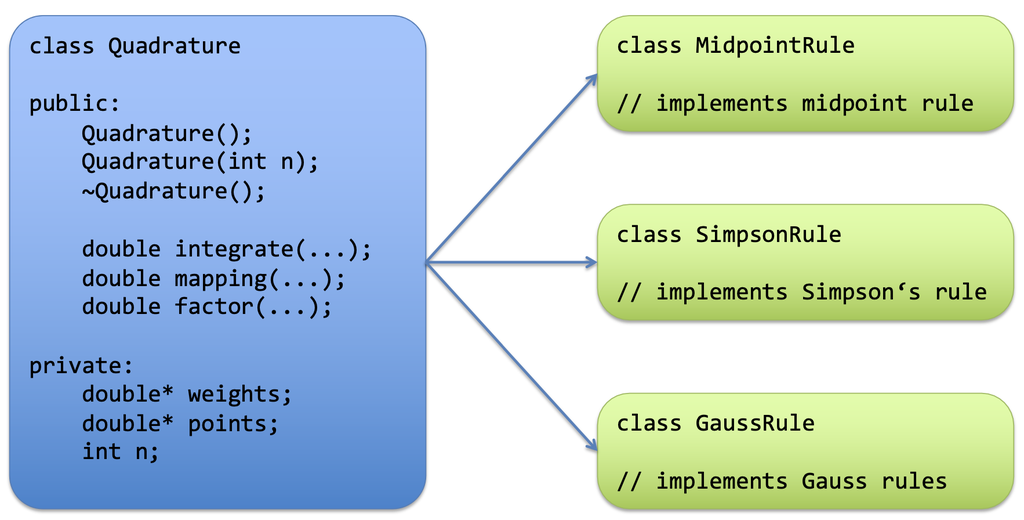

# Base class `Quadrature`

```
class Quadrature
{
    public:
        Quadrature()
        : n(0), weights(nullptr), points(nullptr) {};

        Quadrature(int n)
        : n(n), weights(new double[n]), points(new double[n]) {};

        ~Quadrature()
        { delete[] weights; delete[] points; n=0; }

    private:
        double* weights;
        double* points;
        int     n;
};
```

*Scenario I:* We want to **declare the interface** of the integrate function but we want to *force* the user to implement each integration rule individually

```
// pure (=0) virtual member functions
virtual double integrate(double (*func)(double x), double a, double b) const = 0;
virtual double integrate(std::function<double(double)> func, double a, double b) const  = 0;
```

- Keyword `virtual ... = 0;` declares the function to be **pure virtual**
- That is, each class that is derived from the **abstract class** `Quadrature` must(!!!) implement this function explicitly
- Otherwise, the compiler complains when the programmer forgets to implement a pure virtual function and tries to create an object of the derived but not fully implemented class

# Abstract classes

A class with at least one pure virtual function is an **abstract class** and it is not possible to create an object thereof

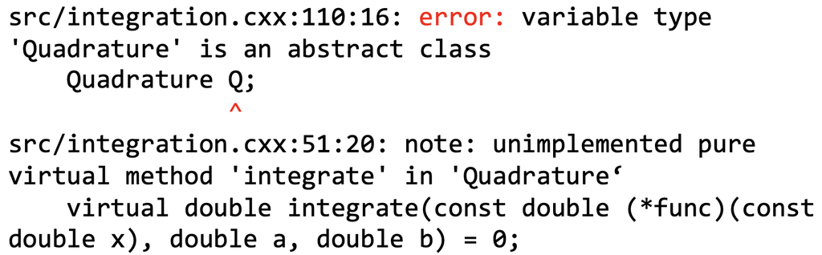

# Base class `Quadrature`

*Scenario II:* We provide a *generic implementation* but allow the user to override it explicitly in a derived class

```
// virtual memper functions
virtual double integrate(double (*func)(double x), double a, double b) const {...}
virtual double integrate(std::function<double(double)> func, double a, double b) const {...}
```

- Keyword `virtual` declares the function **virtual**. Virtual functions *can* be overridden in a derived class. If no overriding takes place, then the function implementation from the base class is used

```
class Quadrature {
    private:
        double* weights;
        double* points;
        int     n;

    public:
        Quadrature()
        : n(0), weights(nullptr), points(nullptr) {};

        Quadrature(int n)
        : n(n), weights(new double[n]), points(new double[n]) {};

        ~Quadrature()
        { delete[] weights; delete[] points; n=0; }

    // pure virtual functions (must be implemented in derived class)
    virtual double mapping(double xi, double a, double b) const = 0;
    virtual double factor(double a, double b) const = 0;

    // virtual function (generic implementation)
    virtual double integrate(double (*func)(double x), double a, double b) const {
        double integral(0.0);
        for (auto i=0; i<n; i++)
            integral += weights[i]*func(mapping(points[i],a,b));
        return factor(a,b)*integral;
    }
};
```

# Class `MidpointRule`

- **Derive** class `MidpointRule` from base class `Quadrature`

```
class MidpointRule : public Quadrature
{
    // Implement pure virtual functions (not used but need to be implemented!)
    virtual double mapping(double xi, double a, double b) const  { return 0; }
    virtual double factor(double a, double b) const { return 1; }

    // Override the implementation of the virtual integrate
    // function from class Quadrature with own implementation
    virtual double integrate(double (*func)(double x), double a, double b) const
    {
        return (b-a) * func( 0.5 * (a+b) );
    }
};
```

# Class `SimpsonRule`

- **Derive** class `SimpsonRule` from base class `Quadrature`

```
class SimpsonRule : public Quadrature
{
    // Implement pure virtual functions (not used but need to be implemented!)
    virtual double mapping(double xi, double a, double b) const  { return 0; }
    virtual double factor(double a, double b) const { return 1; }

    // Override the implementation of the virtual integrate
    // function from class Quadrature with own implementation
    virtual double integrate(double (*func)(double x), double a, double b) const
    {
        return (b-a)/6.0 * ( func(a) + 4.0 * func( 0.5*(a+b) ) + func(b) );
    }
};
```

# Class `GaussRule`

**Derive** class `GaussRule` from base class `Quadrature`

```
class GaussRule : publixc Quadrature {
    GaussRule(int n) : Quadrature(n) {
        switch (n) {
            case 1:
                weights[0] = { 2.0 }; // QUIZ: Do we have access to the
                points[0]  = { 0.0 }; // attributes weights and points ?
                break;
            case 2:
                ...
            default:
                throw "Invalid argument";
        }
    }
};
```

# Program design, revisited

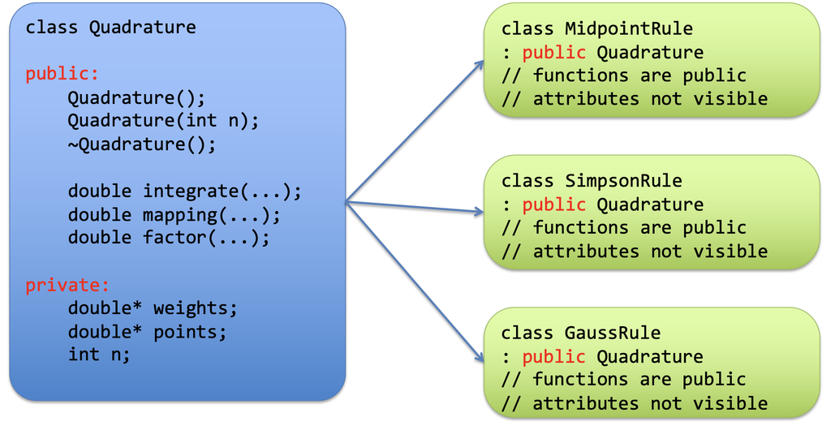

# Program design, revisited

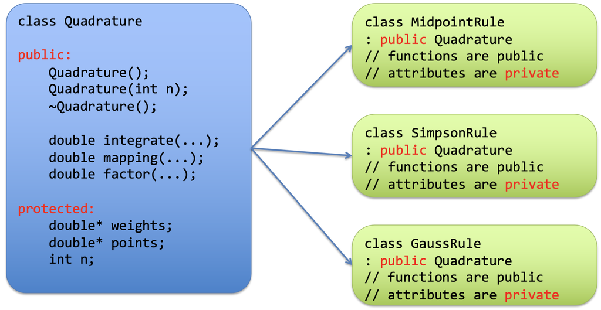

# Class `GaussRule`

- Attributes from base class are now visible in derived class
- Class `GaussRule` implements functions `factor` and `mapping`
- Class `GaussRule` inherits the virtual function `integrate` from class `Quadrature`

```
class GaussRule : public Quadrature
{
    virtual double factor(double a, double b) const
    { return 0.5 * (b-a); }

    virtual double mapping(double xi, double a, double b) const
    { return 0.5 * (b-a) * xi + 0.5 * (a+b); }
};
```

# Keyword: `override` (C++11)

- With the `override` keyword you can force the compiler to explicitly check that the function in a derived class **overrides** a (pure) virtual function from the base class

```
class GaussRule : public Quadrature
{
    virtual double factor(double a, double b) const override
    {
        return 0.5 * (b - a);
    }
};
```

- If the base class Quadrature does not specify a (pure) virtual function `factor` an error will be thrown

# Keyword: `final` (C++11)

- With the `final` keyword you can force the compiler to explicitly prevent further overriding of functions

```
class GaussRule : public Quadrature
{
    virtual double factor(double a, double b) const final
    { return 0.5*(b-a); }
};
```

- If a class `GaussRuleImproved` derived from `GaussRule` tries to override the function `factor` an error will be thrown

```
class GaussRuleImproved : public GaussRule
{
    virtual double factor(double a, double b) const override
    { return 0.5*(b-a); }
};
```